# Series 7 – Fitting a Logistic Regression in Bayes

## Prediction of gender by height and weight with sparse data. Robust model

Repeat the same comparison with the sparse data.

Create data list with one predictor.

```r
heightWeightSparseDataList <- list(Ntotal = nrow(mydf_sparse),
                                   y = mydf_sparse$male,
                                   x = cbind(mydf_sparse$height),
                                   Nx = 1)
```

Fit both models with only one predictor `height`

```r
fitSparse <- sampling(stanDsoLogistic,
                       data=heightWeightSparseDataList,
                       pars=c('beta0', 'beta'),
                       iter=5000, chains = 2, cores = 2)

fitSparseRobust <- sampling(stanDsoRobustLogistic,
                data=heightWeightSparseDataList,
                pars=c('beta0', 'beta', 'guess'),
                iter=5000, chains = 2, cores = 2)
```

Analyze the models.

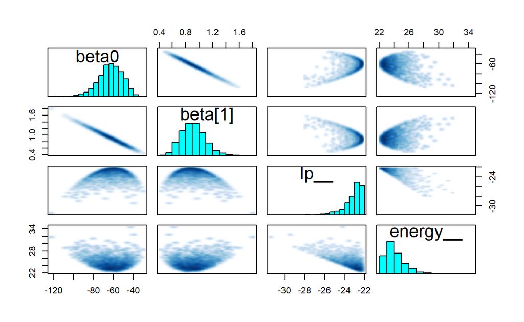

```r
pairs(fitSparse)
```

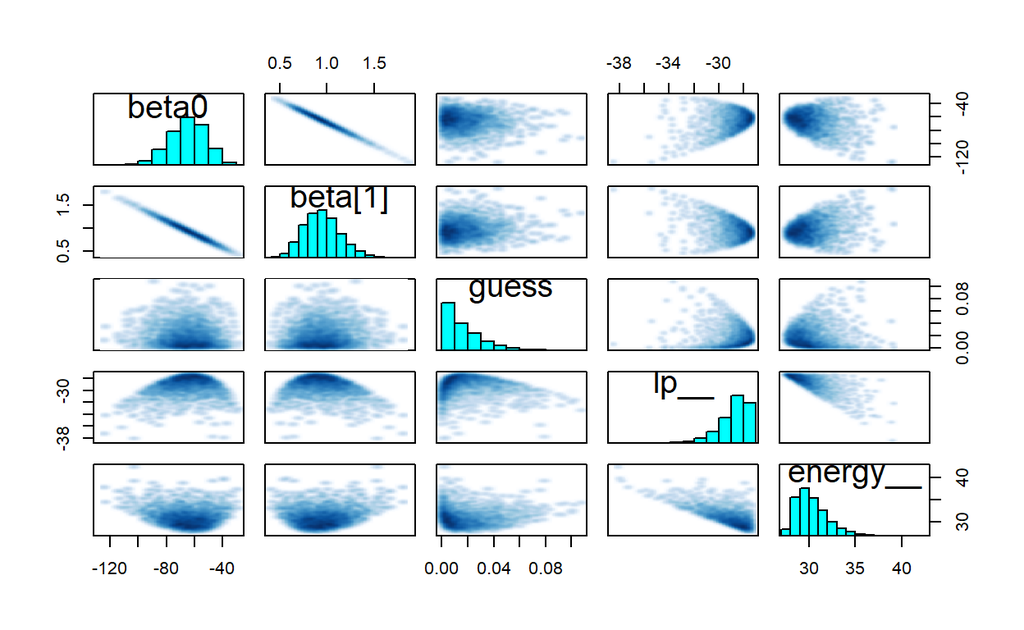

```r
pairs(fitSparseRobust)
```

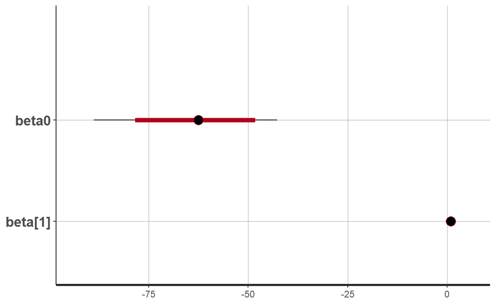

```r
plot(fitSparse)
```

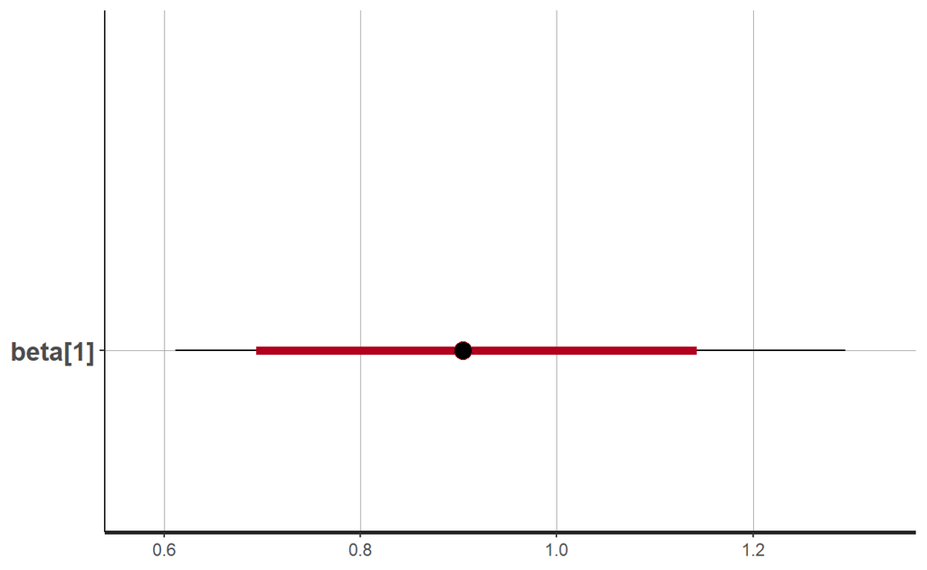

```r
plot(fitSparse,pars=c("beta"))
```

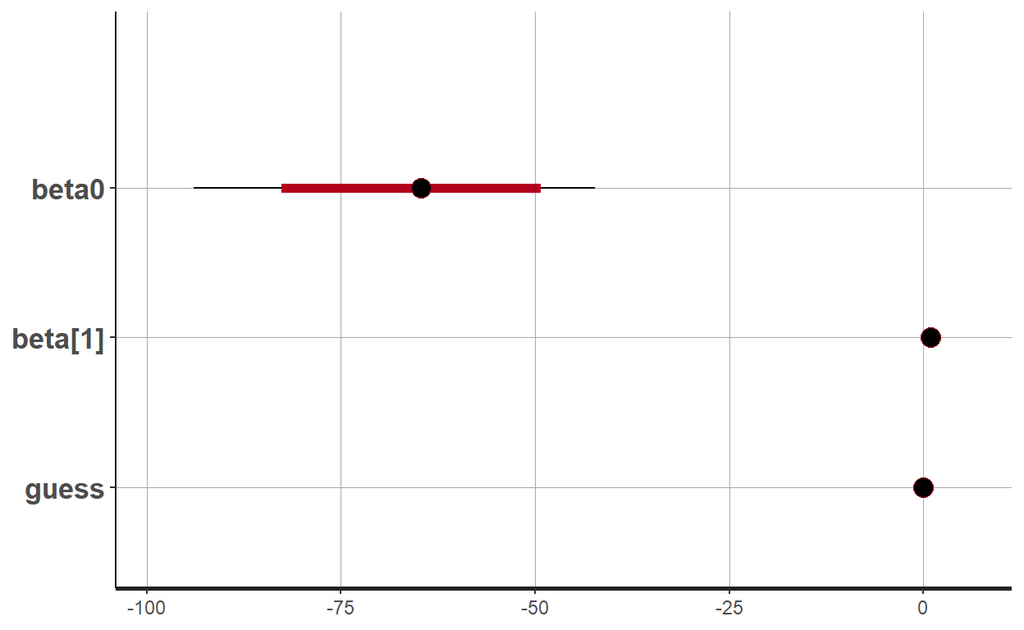

```r
plot(fitSparseRobust)
```

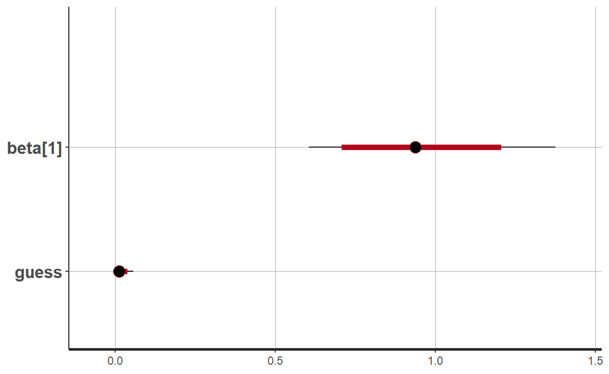

```r
plot(fitSparseRobust,pars=c("beta[1]","guess"))
```

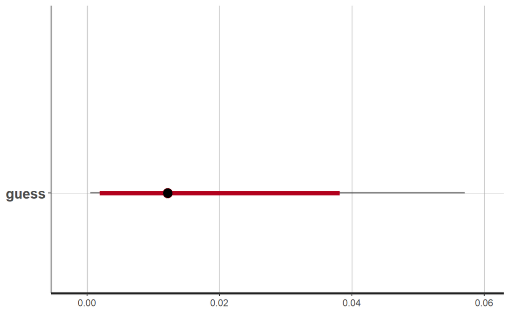

```r
plot(fitSparseRobust,pars=c("guess"))
```

```r
rbind(summary(fitSparseRobust)$summary[,c(1,4,7)],
      summary(fitSparse)$summary[,c(1,4,8)]
)
```

```
                mean          2.5%          75%
beta0   -65.43711171 -9.393761e+01 -56.03873197
beta[1]   0.94912626  6.055210e-01   1.07111437
guess     0.01689194  5.152762e-04   0.02448201
lp__    -28.85479455 -3.232575e+01 -27.89492051
beta0   -63.02455548 -8.871818e+01 -42.69724337
beta[1]   0.91384987  6.114798e-01   1.29416346
lp__    -23.14591098 -2.575415e+01 -22.20307431
```

Make plot of probabilities.

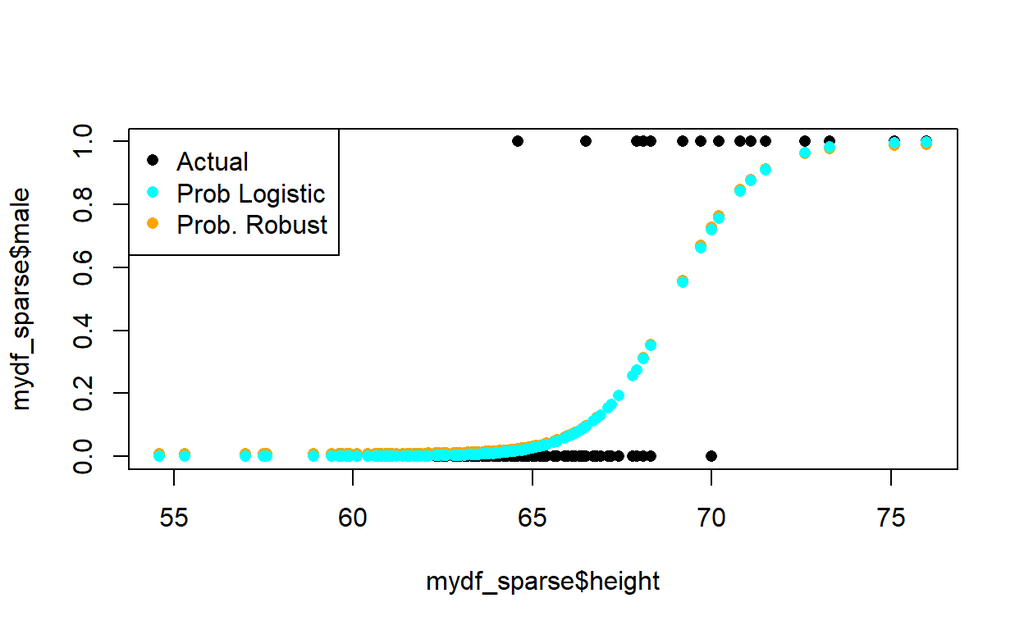

```r
# Coefficients
meanBeta0Robust<-summary(fitSparseRobust)$summary[1,1]
meanBeta1Robust<-summary(fitSparseRobust)$summary[2,1]
guess<-summary(fitSparseRobust)$summary[3,1]
meanBeta0<-summary(fitSparse)$summary[1,1]
meanBeta1<-summary(fitSparse)$summary[2,1]

#Linear predictors and probabilities
linPredRobust_Male.Height<-meanBeta0Robust+meanBeta1Robust*mydf_sparse$height
pRobustMail_height<-guess/2+(1-guess)*exp(linPredRobust_Male.Height)/(1+exp(linPredRobust_Male.Height))
linPred_Male.Height<-meanBeta0+meanBeta1*mydf_sparse$height
pMail_height<-exp(linPred_Male.Height)/(1+exp(linPred_Male.Height))

# Plot
plot(mydf_sparse$height,mydf_sparse$male,pch=16)
points(mydf_sparse$height,pRobustMail_height,col="orange",pch=16)
points(mydf_sparse$height,pMail_height,col="cyan",pch=16)
legend("topleft",
       legend=c("Actual","Prob Logistic","Prob. Robust"),
       col=c("black","cyan","orange"),pch=16)
```

## Anesthesia example

This data example is from library `DAAG.`  
Thirty patients were given an anesthetic agent maintained at a predetermined concentration level (`conc`) for 15 minutes before making an incision. It was then noted whether the patient moved (1), i.e. jerked or twisted.

### Data

```r
library(DAAG)
head(anesthetic)
```

```
  move conc   logconc nomove
1    0  1.0 0.0000000      1
2    1  1.2 0.1823216      0
3    0  1.4 0.3364722      1
4    1  1.4 0.3364722      0
5    1  1.2 0.1823216      0
6    0  2.5 0.9162907      1
```

Use column `move` as response and column `logconc` as predictor.

Prepare the data.

```r
dataListAnesthetic <- list(Ntotal=nrow(anesthetic),
                           y=anesthetic$move,
                           x=cbind(anesthetic$logconc),
                           Nx=1)
```

### Logistic model by `glm()`

```r
logRegr <- glm(move ~ logconc,
               data=anesthetic,
               family="binomial")
summary(logRegr)
```

```
Call:
glm(formula = move ~ logconc, family = "binomial", data = anesthetic)

Deviance Residuals:
    Min       1Q   Median       3Q      Max
-2.1477  -0.6962  -0.1209   0.7586   1.7528

Coefficients:
            Estimate Std. Error z value Pr(>|z|)
(Intercept)   0.8077     0.5709   1.415  0.15715
logconc      -6.2457     2.2618  -2.761  0.00575 **
---
Signif. codes:  0 '***' 0.001 '**' 0.01 '*' 0.05 '.' 0.1 ' ' 1

(Dispersion parameter for binomial family taken to be 1)

    Null deviance: 41.455  on 29  degrees of freedom
Residual deviance: 28.007  on 28  degrees of freedom
AIC: 32.007

Number of Fisher Scoring iterations: 5
```

```r
predLogRegr <- predict(logRegr, type="response")
```

### Running chains

Run MCMC using logistic and robust logistic models.

```r
fitAnesth <- sampling(stanDsoLogistic,
                data=dataListAnesthetic,
                pars=c('beta0', 'beta'),
                iter=5000, chains = 2, cores = 2
)

fitRobustAnesth <- sampling(stanDsoRobustLogistic,
                             data=dataListAnesthetic,
                              pars=c('beta0', 'beta', 'guess'),
                              iter=5000, chains = 2, cores = 2)
```

### Analysis of logistic model

Extract diagnostics

```r
summary(fitAnesth)$summary[,c(1,4,8:10)]
```

```
               mean        2.5%      97.5%    n_eff      Rhat
beta0     0.8198095  -0.2232116   2.005003 3877.299 0.9998678
beta[1]  -6.1749593 -10.8825706  -2.377365 3117.371 1.0000402
lp__    -15.4911255 -18.3350197 -14.471061 1721.835 1.0022634
```

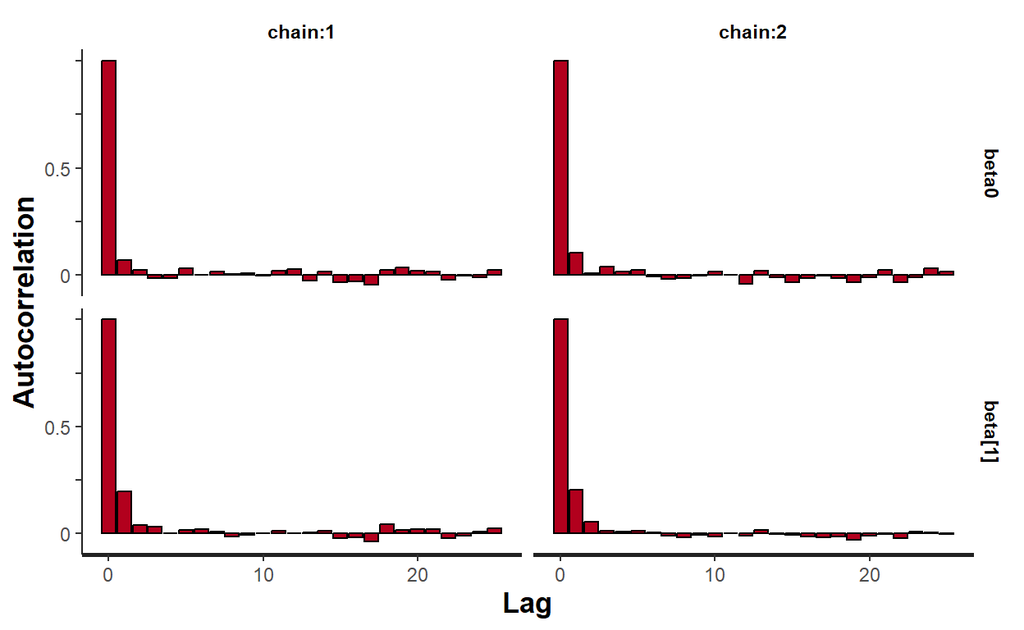

```r
stan_ac(fitAnesth, separate_chains = T)
```

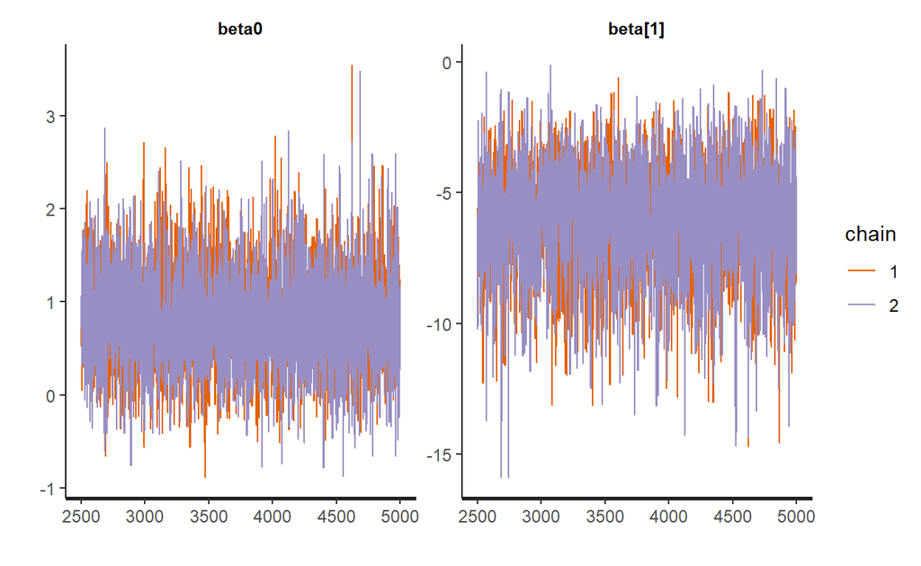

```r
stan_trace(fitAnesth)
```

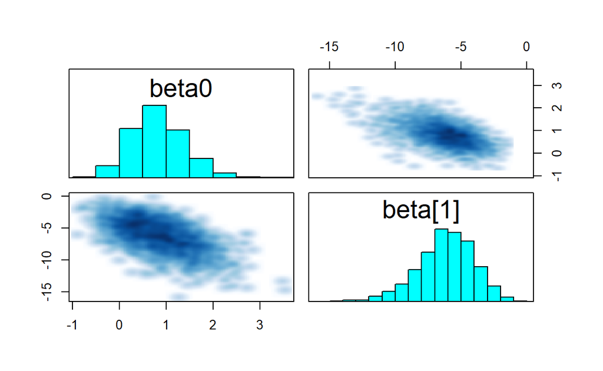

```r
pairs(fitAnesth,pars=c("beta0","beta"))
```

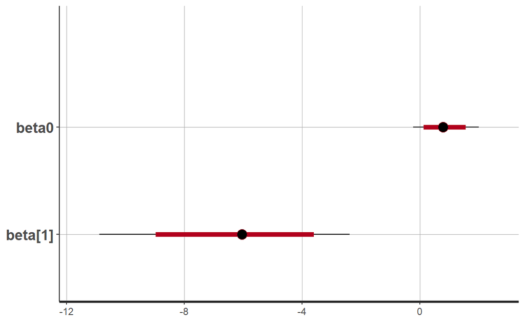

```r
plot(fitAnesth)
```

### Analysis of robust logistic model

```r
summary(fitRobustAnesth)$summary[,c(1,4,8:10)]
```

```
                mean          2.5%       97.5%    n_eff      Rhat
beta0     1.02591748  -0.206024406   2.6568493 2882.397 1.0010848
beta[1]  -7.40456341 -14.191363295  -2.7011459 2542.829 1.0008553
guess     0.09682537   0.003829574   0.2914329 4230.349 0.9996954
lp__    -19.49792255 -22.837487799 -18.0184837 1903.465 1.0013869
```

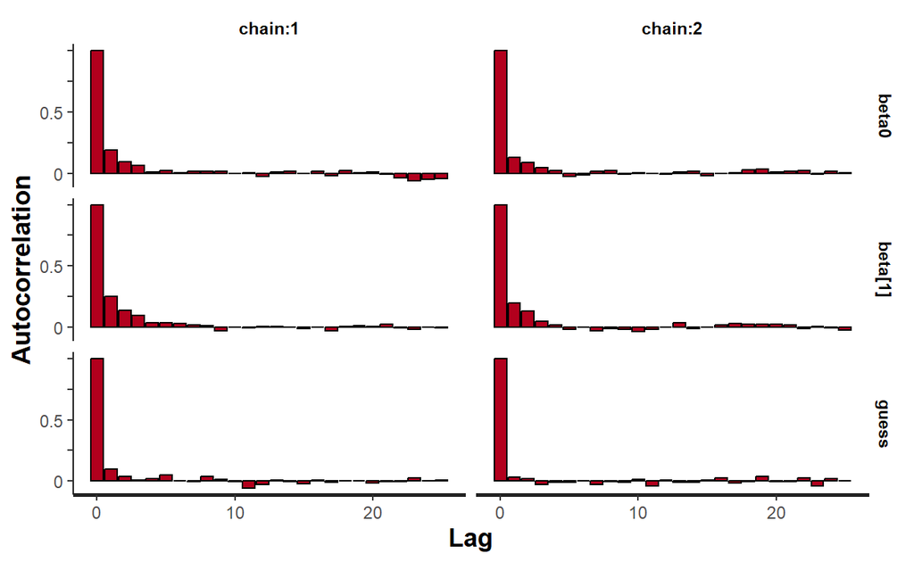

```r
stan_ac(fitRobustAnesth, separate_chains = T)
```

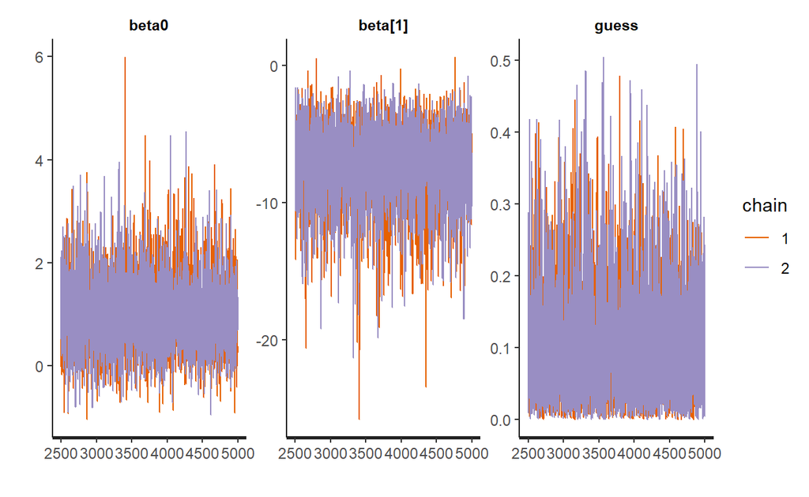

```r
stan_trace(fitRobustAnesth)
```

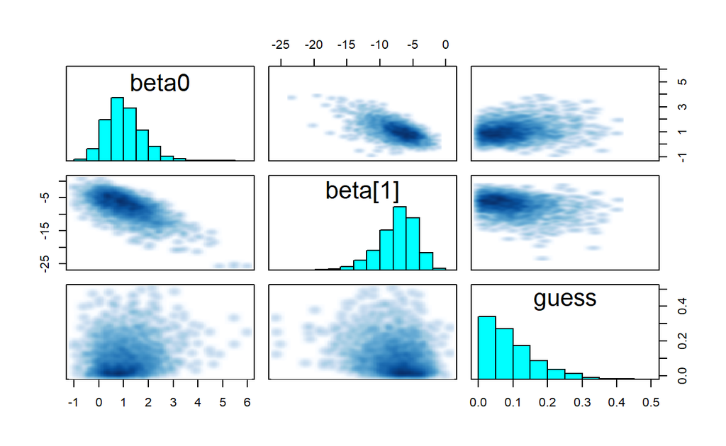

```r
pairs(fitRobustAnesth,pars=c("beta0","beta","guess"))
```

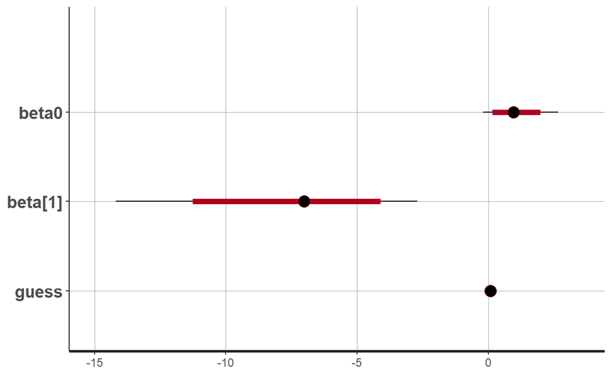

```r
plot(fitRobustAnesth)
```

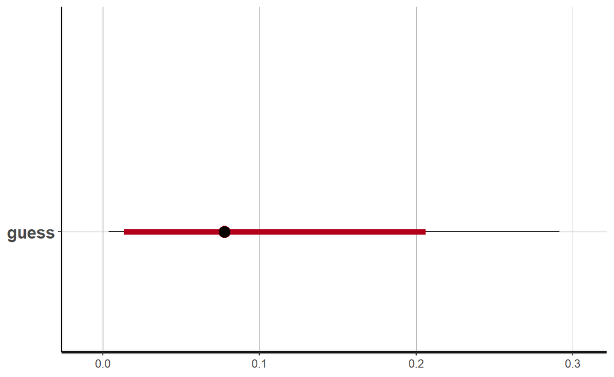

```r
plot(fitRobustAnesth,pars=c("guess"))
```

Parameter guess is almost $10%$. This means that there should be a significant difference between the two models.  
However, 95% HDI almost covers $0$.

### Comparison of logistic and robust logistic models

Compare intercepts.

```r
rbind(Logistic=summary(fitAnesth)$summary[1,c(1,4,8)],
      Robust=summary(fitRobustAnesth)$summary[1,c(1,4,8)])
```

```
              mean       2.5%    97.5%
Logistic 0.8198095 -0.2232116 2.005003
Robust   1.0259175 -0.2060244 2.656849
```

Compare slopes.

```r
rbind(Logistic=summary(fitAnesth)$summary[2,c(1,4,8)],
      Robust=summary(fitRobustAnesth)$summary[2,c(1,4,8)])
```

```
              mean      2.5%     97.5%
Logistic -6.174959 -10.88257 -2.377365
Robust   -7.404563 -14.19136 -2.701146
```

Compare probabilities.

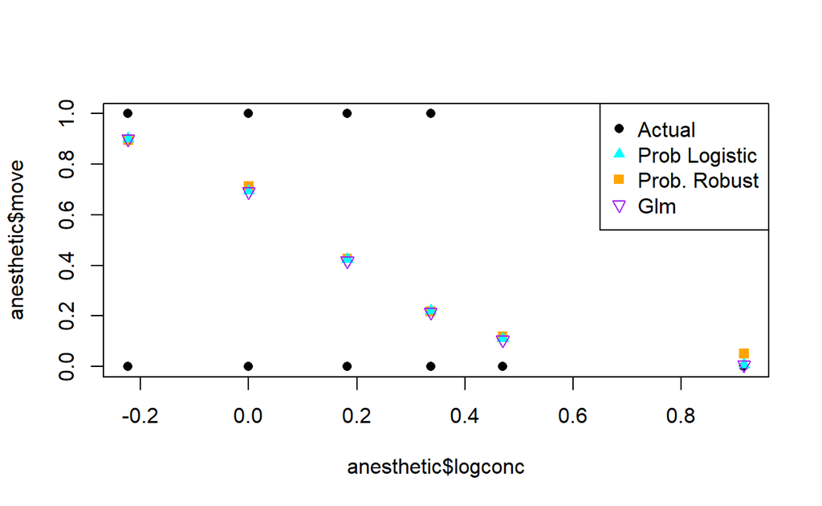

```r
# Coefficients
meanBeta0Robust<-summary(fitRobustAnesth)$summary[1,1]
meanBeta1Robust<-summary(fitRobustAnesth)$summary[2,1]
guess<-summary(fitRobustAnesth)$summary[3,1]
meanBeta0<-summary(fitAnesth)$summary[1,1]
meanBeta1<-summary(fitAnesth)$summary[2,1]

#Linear predictors and probabilities
linPredRobust_Move<-meanBeta0Robust+meanBeta1Robust*anesthetic$logconc
pRobustMove<-guess/2+(1-guess)*exp(linPredRobust_Move)/(1+exp(linPredRobust_Move))
linPred_Move<-meanBeta0+meanBeta1*anesthetic$logconc
pMove<-exp(linPred_Move)/(1+exp(linPred_Move))

# Plot
plot(anesthetic$logconc,anesthetic$move,pch=16)
points(anesthetic$logconc,pRobustMove,col="orange",pch=15)
points(anesthetic$logconc,pMove,col="cyan",pch=17)
points(anesthetic$logconc,predLogRegr,col="purple",pch=25)
legend("topright",
       legend=c("Actual","Prob Logistic","Prob. Robust","Glm"),
       col=c("black","cyan","orange","purple"),pch=c(16,17,15,25))
```

Again, robust method does not return extreme probabilities.

# Softmax regression

Softmax (or multinomial logistic regression) is a generalization of logistic regression to the case where we want to handle multiple classes. In logistic regression, the response was binary: $y^{(i)} \in \{0,1\}$, meanwhile softmax handles $y^{(i)} \in \{1, ..., K\}$

It is based on modification of odds ratio from
$$\frac{p}{1-p}$$
to
$$\frac{p_s}{p_r},$$
where $p_r$ is probability of one of several classes selected as reference (for example, control group).

The model changes very little from logistic regression and is shown on this diagram.

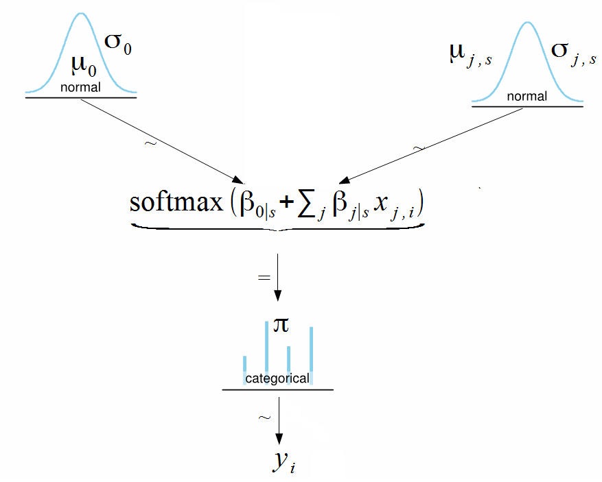

Because adding constants to coefficients does not change softmax the reference class coefficients are assumed equal to zero.

## Simulated data from the book

```r
myData <- read.csv(file="data/SoftmaxRegData2.csv" )
head(myData)
```

```
           X1         X2 Y
1 -0.08714736 -1.0813422 2
2 -0.72256565 -1.5838631 2
3  0.17918961  0.9717904 3
4 -1.15975176  0.5026244 3
5 -0.72711762  1.3757045 3
6  0.53341559  1.7746506 3
```

```r
table(myData$Y, useNA = "always")
```

```
   1    2    3    4 <NA>
  58  145  139  133    0
```

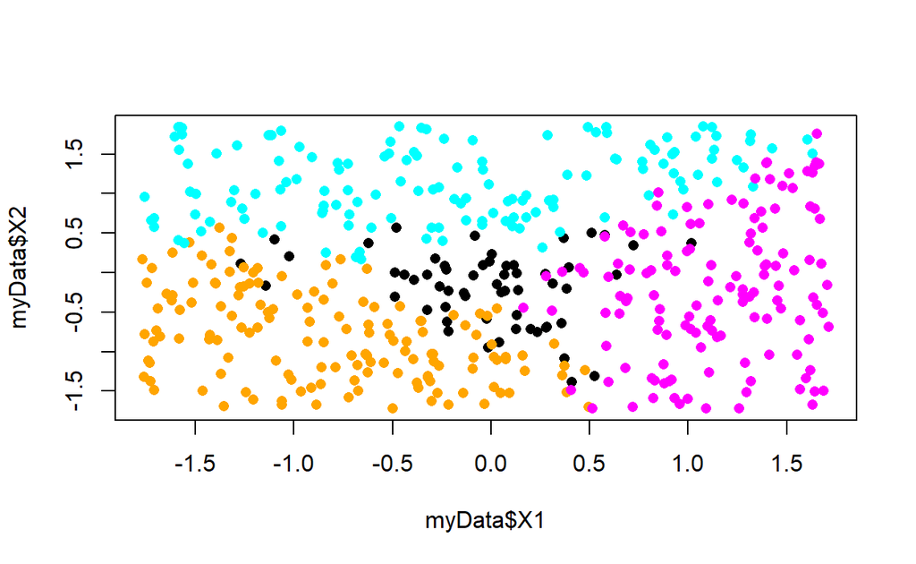

```r
idx2<-myData$Y==2
idx3<-myData$Y==3
idx4<-myData$Y==4

plot(myData$X1,myData$X2,pch=16)
points(myData$X1[idx2],myData$X2[idx2],pch=16,col="orange")
points(myData$X1[idx3],myData$X2[idx3],pch=16,col="cyan")
points(myData$X1[idx4],myData$X2[idx4],pch=16,col="magenta")
```

Prepare data list

```r
dataListSoftmax<-list(N=nrow(myData),  # num of observations
                          K=max(myData$Y), # num of groups
                          y=myData$Y,
                          x=cbind(x1 = myData$X1, x2 = myData$X2),
                          D=2)  # num of predictiors
```

## Softmax model

Describe the model.

```r
modelString="
data {
    int<lower=2> K;  // num of groups
    int<lower=0> N;  // num of observations
    int<lower=1> D;  // num of predictors
    int<lower=1,upper=K> y[N];
    matrix[N, D] x;
}
transformed data {
    row_vector[D] zeros;
    row_vector[D] x_m;  // x means
    row_vector[D] x_sd; // x standard deviations
    matrix[N, D] zx;    // normalized x
    zeros = rep_row_vector(0, D); // coefficients are zeros for the baseline class
    for (j in 1:D) {
        x_m[j] = mean(x[,j]);
        x_sd[j] = sd(x[,j]);
        zx[,j] = (x[,j] - x_m[j]) / x_sd[j];
    }
}
parameters {
    matrix[K-1,D] zbeta_raw;  // K-1 makes model identifiable
    vector[K-1] zbeta0_raw;
}
transformed parameters {
    vector[K] zbeta0;   // intersection coeffs
    matrix[K, D] zbeta; // predictor coeffs
    zbeta0 = append_row(0, zbeta0_raw);
    zbeta = append_row(zeros, zbeta_raw); // add zeros for coefficients of the baseclass
}
model {
    zbeta0_raw ~ normal(0, 5);
    for (k in 1:(K-1))
        zbeta_raw[k,] ~ normal(0, 5);
    for (n in 1:N)
        y[n] ~ categorical(softmax(zbeta0 + zbeta * to_vector(zx[n,]) ));
}
generated quantities {
    vector[K] beta0;
    matrix[K, D] beta;
    // transform zbetas to original betas:
    for (k in 1:K) {
        beta0[k] = zbeta0[k];
        for (j in 1:D) {
            beta0[k] = beta0[k] - zbeta[k,j] * x_m[j] / x_sd[j];
            beta[k,j] = zbeta[k,j] / x_sd[j];
        }
     }
}
"
```

Create DSO.

```r
modelSoftmax <- stan_model(model_code=modelString)
save(modelSoftmax, file = "data/stanSoftmaxDso.Rds")
```

```r
load("data/stanSoftmaxDso.Rds")
```

```r
fit <- sampling(modelSoftmax,
                data=dataListSoftmax,
                pars=c('beta0', 'beta'),
                iter=5000, chains = 2, cores = 2)
```

## Analysis

Analyze fitted model using `shinystan`, but check directly for purposely demonstration.

```r
summary(fit)$summary[,c(1,4,8:10)]
```

```
                  mean        2.5%        97.5%    n_eff      Rhat
beta0[1]     0.0000000    0.000000    0.0000000      NaN       NaN
beta0[2]    -3.8747761   -5.287726   -2.6498584 2424.806 1.0004543
beta0[3]    -3.4383430   -4.758058   -2.2832007 3046.880 1.0003798
beta0[4]    -3.8239785   -5.174666   -2.6048550 2777.099 1.0014128
beta[1,1]    0.0000000    0.000000    0.0000000      NaN       NaN
beta[1,2]    0.0000000    0.000000    0.0000000      NaN       NaN
beta[2,1]   -5.5258762   -7.266858   -4.0493728 2509.455 1.0003697
beta[2,2]   -5.3813396   -7.078252   -3.9099912 2562.798 1.0001610
beta[3,1]   -1.4477120   -2.502389   -0.4137045 3499.414 1.0012289
beta[3,2]    8.7504970    6.700614   11.0491097 2771.076 0.9998857
beta[4,1]    8.1935589    6.190566   10.3753359 3002.059 1.0013696
beta[4,2]   -0.7384386   -1.710137    0.1956379 3498.552 1.0011204
lp__      -123.5101370 -128.879940 -120.2345545 2018.045 1.0005849
```

The model has 4 classes and 2 predictors. The returned coefficients form a matrix
$$\lambda_{i,1} = \beta_{0,1} +
\beta{1,1} x_{i,1} + \beta_{2,1} x_{i,2} \\
\lambda_{i,2} = \beta_{0,2} + \beta{1,2} x_{i,1} + \beta_{2,2} x_{i,2}
\\
\lambda_{i,3} = \beta_{0,3} + \beta{1,3} x_{i,1} + \beta_{2,31} x_{i,2}
\\
\lambda_{i,4} = \beta_{0,4} + \beta{1,4} x_{i,1} + \beta_{2,4}
x_{i,2}$$

In this system first class is selected as reference, so $\beta_{0,1} = \beta_{1,1} = \beta_{2,1} = 0$.

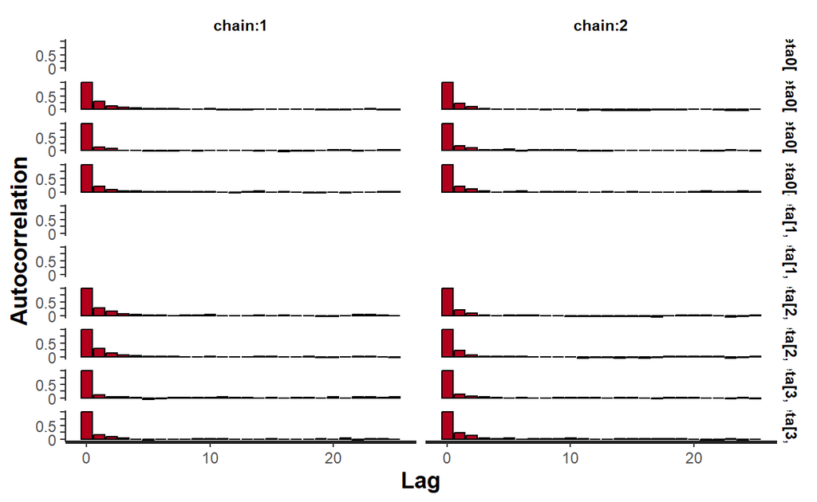

```r
stan_ac(fit, separate_chains = T)
```

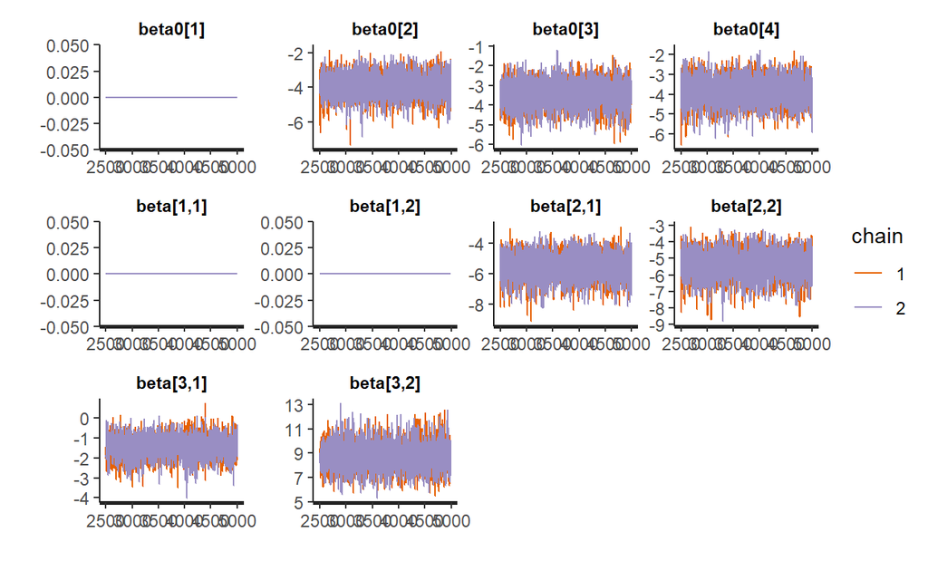

```r
stan_trace(fit)
```

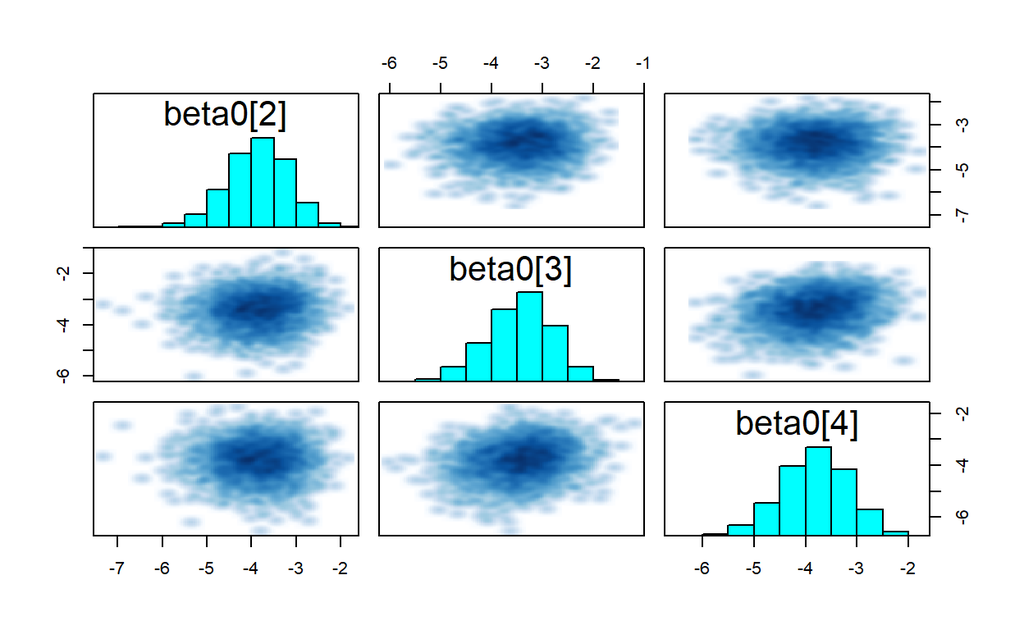

```r
pairs(fit,pars=c("beta0"))
```

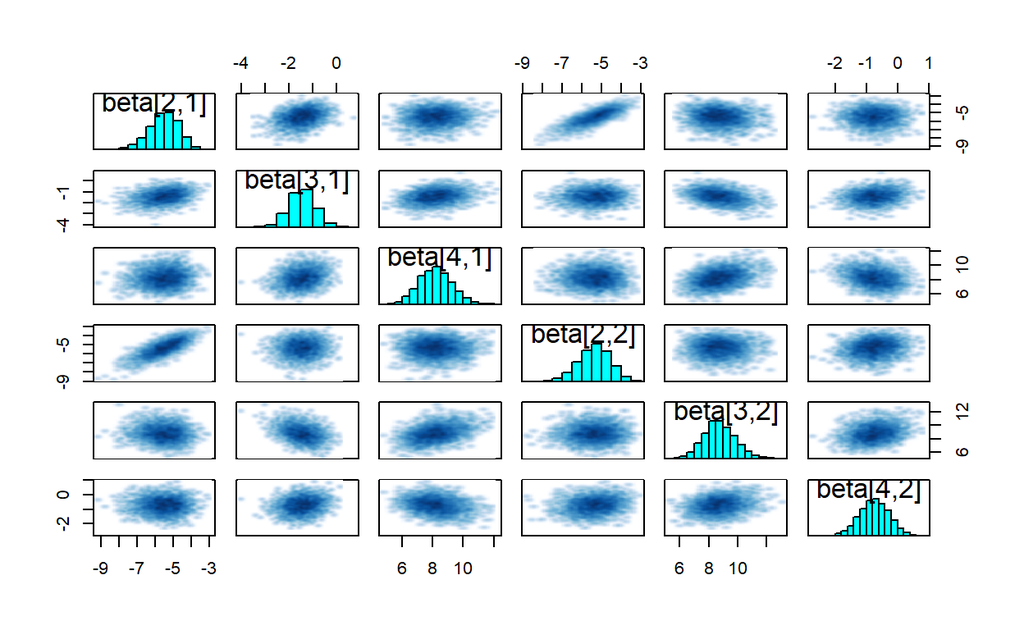

```r
pairs(fit,pars=c("beta"))
```

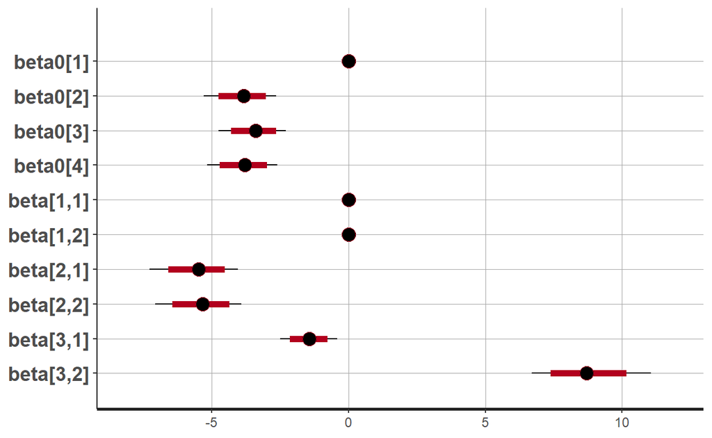

```r
plot(fit)
```

## Classification

To predict classes use formula for probability of class $k$
$$p_k =
\frac{e^{\lambda_k}}{\sum_s e^{\lambda_s}}.$$

Create matrix of coefficients.

```r
SoftmaxCoeff<-summary(fit)$summary[1:12,c(1)]
SoftmaxCoeff<-cbind(SoftmaxCoeff[1:4],matrix(SoftmaxCoeff[-(1:4)],ncol=2,byrow=T))
rownames(SoftmaxCoeff)<-paste0("Class",1:4)
SoftmaxCoeff
```

```
            [,1]      [,2]       [,3]
Class1  0.000000  0.000000  0.0000000
Class2 -3.874776 -5.525876 -5.3813396
Class3 -3.438343 -1.447712  8.7504970
Class4 -3.823979  8.193559 -0.7384386
```

Create linear predictors.

```r
head(myData)
```

```
           X1         X2 Y
1 -0.08714736 -1.0813422 2
2 -0.72256565 -1.5838631 2
3  0.17918961  0.9717904 3
4 -1.15975176  0.5026244 3
5 -0.72711762  1.3757045 3
6  0.53341559  1.7746506 3
```

```r
linPredictors<-apply(SoftmaxCoeff[,-1],1,function(z) z%*%t(myData[,1:2]))
dim(linPredictors)
```

```
[1] 475   4
```

```r
head(linPredictors)
```

```
     Class1     Class2     Class3      Class4
[1,]      0   6.300635  -9.336117  0.08445775
[2,]      0  12.516113 -12.813522 -4.75079860
[3,]      0  -6.219714   8.244234  0.75059308
[4,]      0   3.703852   6.077200 -9.87365165
[5,]      0  -3.385171  13.090755 -6.97355432
[6,]      0 -12.497586  14.756843  3.06010158
```

```r
linPredictors<-t(apply(linPredictors,1,function(z) z+SoftmaxCoeff[,1]))
dim(linPredictors)
```

```
[1] 475   4
```

```r
head(linPredictors)
```

```
     Class1      Class2     Class3      Class4
[1,]      0   2.4258589 -12.774460  -3.7395208
[2,]      0   8.6413373 -16.251865  -8.5747771
[3,]      0 -10.0944901   4.805891  -3.0733854
[4,]      0  -0.1709239   2.638857 -13.6976302
[5,]      0  -7.2599471   9.652412 -10.7975328
[6,]      0 -16.3723623  11.318500  -0.7638769
```

Check calculation for the first row of the data and second class.

```r
row1<-myData[1,]
Class2<-SoftmaxCoeff[2,1]+SoftmaxCoeff[2,2]*row1[1]+SoftmaxCoeff[2,3]*row1[2]
c(Class2,linPredictors[1,2])
```

```
$X1
[1] 2.425859

$Class2
[1] 2.425859
```

Create probabilities

```r
softmaxProb<-exp(linPredictors)/apply(exp(linPredictors),1,sum)
apply(head(softmaxProb),1,sum)
```

```
[1] 1 1 1 1 1 1
```

Predict classes.

```r
predClass<-apply(softmaxProb,1,which.max)
head(predClass)
```

```
[1] 2 2 3 3 3 3
```

Plot predicted classes and compare them with the data.

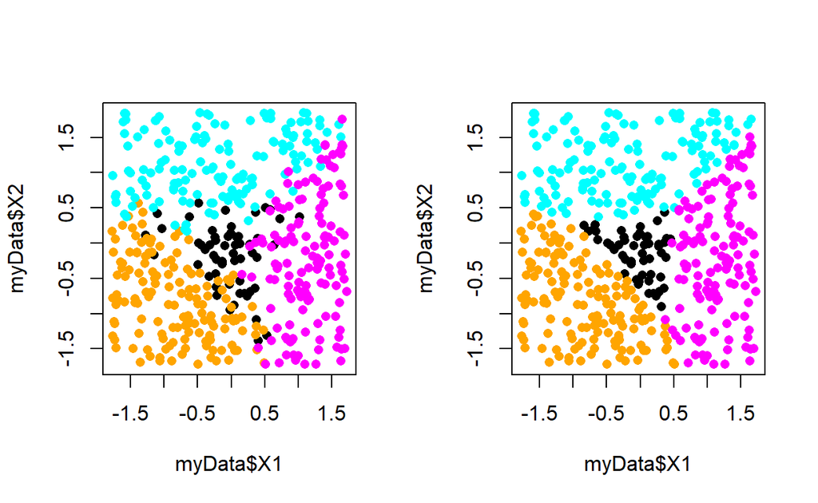

```r
idx2Pred<-predClass==2
idx3Pred<-predClass==3
idx4Pred<-predClass==4

par(mfrow=c(1,2))
plot(myData$X1,myData$X2,pch=16)
points(myData$X1[idx2],myData$X2[idx2],pch=16,col="orange")
points(myData$X1[idx3],myData$X2[idx3],pch=16,col="cyan")
points(myData$X1[idx4],myData$X2[idx4],pch=16,col="magenta")

plot(myData$X1,myData$X2,pch=16)
points(myData$X1[idx2Pred],myData$X2[idx2Pred],pch=16,col="orange")
points(myData$X1[idx3Pred],myData$X2[idx3Pred],pch=16,col="cyan")
points(myData$X1[idx4Pred],myData$X2[idx4Pred],pch=16,col="magenta")
```

```r
par(mfrow=c(1,1))
```

See how different classes are separated by hyperplanes.

Add hyperplane between class 1 and class 2:

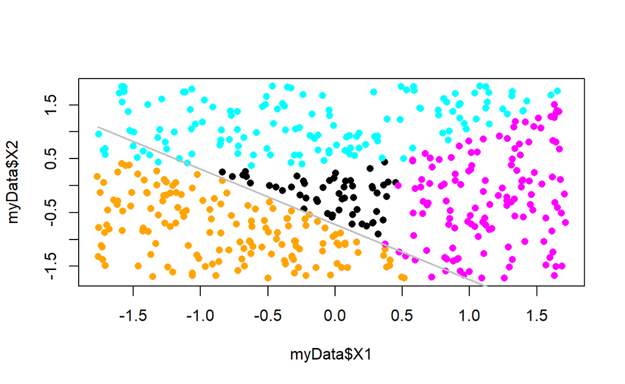

```r
plot(myData$X1,myData$X2,pch=16)
points(myData$X1[idx2Pred],myData$X2[idx2Pred],pch=16,col="orange")
points(myData$X1[idx3Pred],myData$X2[idx3Pred],pch=16,col="cyan")
points(myData$X1[idx4Pred],myData$X2[idx4Pred],pch=16,col="magenta")
lines(myData$X1,-(SoftmaxCoeff[2,1]+SoftmaxCoeff[2,2]*myData$X1)/SoftmaxCoeff[2,3],col="grey")
```

Add hyperplane between class 1 and class 3.

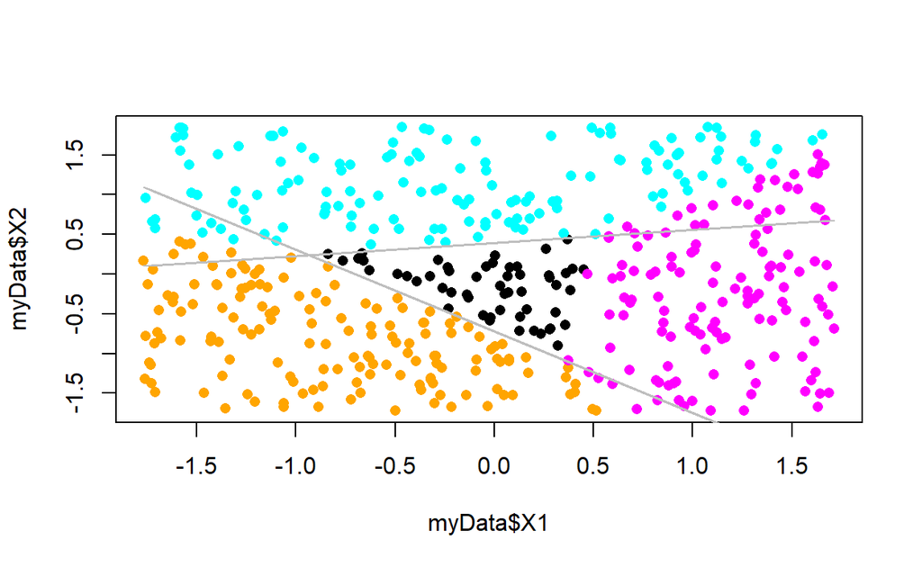

```r
plot(myData$X1,myData$X2,pch=16)
points(myData$X1[idx2Pred],myData$X2[idx2Pred],pch=16,col="orange")
points(myData$X1[idx3Pred],myData$X2[idx3Pred],pch=16,col="cyan")
points(myData$X1[idx4Pred],myData$X2[idx4Pred],pch=16,col="magenta")
lines(myData$X1,-(SoftmaxCoeff[2,1]+SoftmaxCoeff[2,2]*myData$X1)/SoftmaxCoeff[2,3],col="grey")
lines(myData$X1,-(SoftmaxCoeff[3,1]+SoftmaxCoeff[3,2]*myData$X1)/SoftmaxCoeff[3,3],col="grey")
```

Add hyperplane between class 1 and class 4.

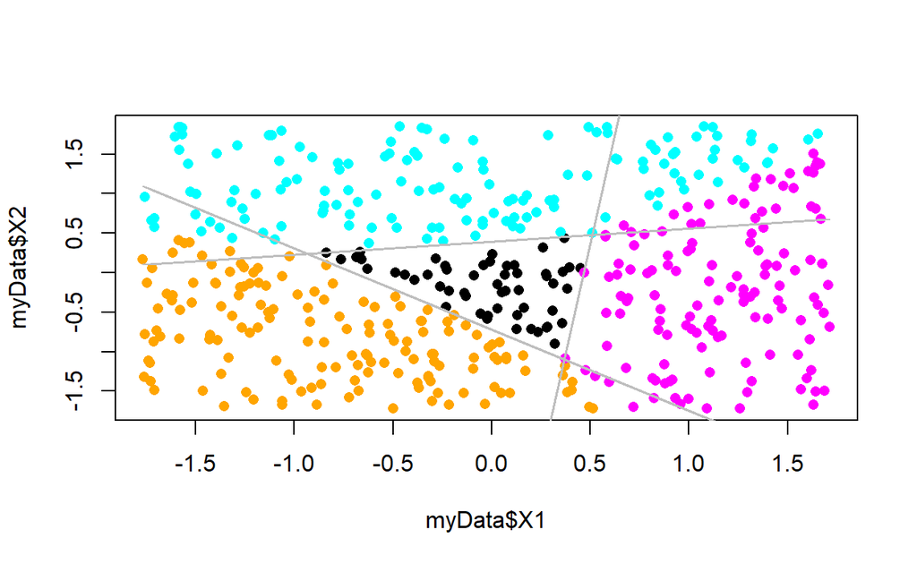

```r
plot(myData$X1,myData$X2,pch=16)
points(myData$X1[idx2Pred],myData$X2[idx2Pred],pch=16,col="orange")
points(myData$X1[idx3Pred],myData$X2[idx3Pred],pch=16,col="cyan")
points(myData$X1[idx4Pred],myData$X2[idx4Pred],pch=16,col="magenta")
lines(myData$X1,-(SoftmaxCoeff[2,1]+SoftmaxCoeff[2,2]*myData$X1)/SoftmaxCoeff[2,3],col="grey")
lines(myData$X1,-(SoftmaxCoeff[3,1]+SoftmaxCoeff[3,2]*myData$X1)/SoftmaxCoeff[3,3],col="grey")
lines(myData$X1,-(SoftmaxCoeff[4,1]+SoftmaxCoeff[4,2]*myData$X1)/SoftmaxCoeff[4,3],col="grey")
```

# Further reading

- Bayesian Methods, UC’s lecture
- Kruschke, John K. Doing Bayesian Data Analysis: a Tutorial with R, JAGS, and Stan. 2nd ed., Academic Press is an imprint of Elsevier, 2015.